# Homework 4

**Due:** Friday, September 26, 10:00pm on Canvas

**Instructions:**

**Code guidelines:**

- If a question requires code, and code is not provided, you will not receive full credit
- You will be graded on the quality of your code. In addition to being correct, your code should also be easy to read

## Conceptual questions

### Cook’s distance

Below is the output for a logistic regression model, and the Cook’s distance plot for the fitted model.

```
##
## Call:
## glm(formula = y ~ x, family = binomial)
##
## Coefficients:
##             Estimate Std. Error z value Pr(>|z|)
## (Intercept)  -1.4020     0.3251  -4.313 1.61e-05 ***
## x             1.7475     0.3876   4.509 6.52e-06 ***
## ---
## Signif. codes:  0 '***' 0.001 '**' 0.01 '*' 0.05 '.' 0.1 ' ' 1
##
## (Dispersion parameter for binomial family taken to be 1)
##
##     Null deviance: 126.90  on 101  degrees of freedom
## Residual deviance:  89.53  on 100  degrees of freedom
## AIC: 93.53
##
## Number of Fisher Scoring iterations: 5
```

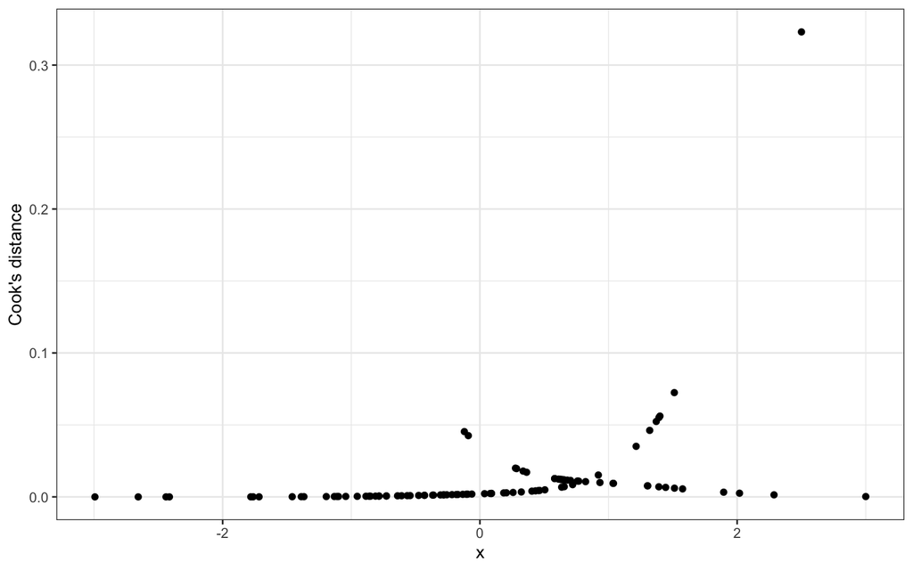

#### Question 1

The largest Cook’s distance is for an observation with $X = 2.5$. However, there is a point with $X = 3$ which has a smaller Cook’s distance. How has this happened? In your answer, use the output provided to discuss what the observed value of $Y$ is for each of these two points.

### Variance inflation factors

Consider a logistic regression model with systematic component

$$\log \left( \dfrac{\pi_i}{1 - \pi_i}
\right) = \beta_0 + \beta_1 X_{i1} + \beta_2 X_{i2} + \cdots + \beta_k
X_{ik}$$

To check for multicollinearity in the explanatory variables (and assess its impact on the estimated coefficients of the model), recall that we can calculate a *variance inflation factor*. The VIF for the $j$th coefficient is defined by

$$VIF_j = \dfrac{Var(\widehat{\beta}_j) \
\text{in the full model (other variables
included)}}{Var(\widehat{\beta}_j) \ \text{when } X_j \text{ is the only
variable in the model}}$$

Suppose we have three explanatory variables, $X_1$, $X_2$, and $X_3$. We fit a logistic regression model with only $X_1$; here are the results:

```r
m1 <- glm(y ~ x1, family = binomial)

summary(m1)
```

```
##
## Call:
## glm(formula = y ~ x1, family = binomial)
##
## Coefficients:
##             Estimate Std. Error z value Pr(>|z|)
## (Intercept) -0.14563    0.09735  -1.496    0.135
## x1           3.28609    0.21212  15.491   <2e-16 ***
## ---
## Signif. codes:  0 '***' 0.001 '**' 0.01 '*' 0.05 '.' 0.1 ' ' 1
##
## (Dispersion parameter for binomial family taken to be 1)
##
##     Null deviance: 1386.29  on 999  degrees of freedom
## Residual deviance:  672.56  on 998  degrees of freedom
## AIC: 676.56
##
## Number of Fisher Scoring iterations: 6
```

From the output, notice that $SE(\widehat{\beta}_1) \approx 0.212$.

We also fit a model with all three variables, and calculate the VIFs:

```r
m2 <- glm(y ~ x1 + x2 + x3, family = binomial)
vif(m2)
```

```
##       x1       x2       x3
## 7.591112 7.067130 7.386217
```

#### Question 2

Using the output provided for the two models, calculate $SE(\widehat{\beta}_1)$ for the *second* model, `m2`.

### Deviance

Below is the output for a logistic regression model:

```r
m1 <- glm(y ~ x1, family = binomial)

summary(m1)
```

```
##
## Call:
## glm(formula = y ~ x1, family = binomial)
##
## Coefficients:
##             Estimate Std. Error z value Pr(>|z|)
## (Intercept)  -0.4769     0.3666  -1.301    0.193
## x1            3.7934     0.7835   4.842 1.29e-06 ***
## ---
## Signif. codes:  0 '***' 0.001 '**' 0.01 '*' 0.05 '.' 0.1 ' ' 1
##
## (Dispersion parameter for binomial family taken to be 1)
##
##     Null deviance: 137.628  on 99  degrees of freedom
## Residual deviance:  59.681  on 98  degrees of freedom
## AIC: 63.681
##
## Number of Fisher Scoring iterations: 6
```

#### Question 3

What is the log-likelihood for the fitted model?

#### Question 4

The estimated coefficients for the model are $\widehat{\beta}_0 = -0.4769$ and $\widehat{\beta}_1 = 3.7934$.

Suppose that instead of these estimated coefficients, I decide I prefer $\widehat{\beta}_0 = -0.5$ and $\widehat{\beta}_1 = 4$ (on the same data). If I calculate the log-likelihood and deviance for the model with these different coefficients, how would they compare to the output shown above? (For each of log-likelihood and deviance, explain whether it will increase, decrease, or stay the same).

We now fit a second model, with two additional explanatory variables:

```r
m2 <- glm(y ~ x1 + x2 + x3, family = binomial)
summary(m2)
```

```
##
## Call:
## glm(formula = y ~ x1 + x2 + x3, family = binomial)
##
## Coefficients:
##             Estimate Std. Error z value Pr(>|z|)
## (Intercept)  -0.5149     0.3790  -1.359    0.174
## x1            3.0398     2.2727   1.338    0.181
## x2           -0.2606     2.6833  -0.097    0.923
## x3            1.0447     2.5467   0.410    0.682
##
## (Dispersion parameter for binomial family taken to be 1)
##
##     Null deviance: 137.63  on 99  degrees of freedom
## Residual deviance:  59.47  on 96  degrees of freedom
## AIC: 67.47
##
## Number of Fisher Scoring iterations: 6
```

```r
vif(m2)
```

```
##        x1        x2        x3
##  8.298274 11.760894 10.903204
```

Comparing the two models (`m1` and `m2` in the displayed output), we notice that while the deviance decreases very slightly, the AIC has *increased* in model 2.

#### Question 5

Explain what is causing the AIC to increase when we add additional variables to the model. Your answer should use information provided by the displayed VIFs.

### Prediction

Your friend has built a logistic regression model to diagnose a rare disease, using a sample of 10000 patients from providers across NC. To assess their model’s predictive ability, they create a confusion matrix:

|  | Disease negative | Disease positive |
| --- | --- | --- |
| Prediction negative | 9501 | 489 |
| Prediction positive | 6 | 4 |

They calculate the overall accuracy of their predictions, and are ecstatic to obtain an accuracy of 95%!

#### Question 6

Should your friend be happy with their model’s predictive performance? Explain why or why not. Your answer should include a discussion of other metrics for assessing predictive ability (such as sensitivity and specificity).

### More prediction

A different friend of yours is feeling ill, and goes to their doctor. Their doctor diagnoses them with a disease called the *Red Death* (what a horrifying name!). Understandably upset, your friend asks about the reliability of the diagnostic test.

In response, their doctor provides a confusion matrix from a recent study on the Red Death:

|  | Disease negative | Disease positive |
| --- | --- | --- |
| Test negative | 8003 | 10 |
| Test positive | 312 | 95 |

The doctor claims that, *if a patient is positive for the disease*, there is a 90.5% chance that they will test positive. Therefore, the doctor argues that your friend is very likely to truly have the disease.

#### Question 7

Using the confusion matrix, explain how the doctor got the 90.5% probability they reported.

#### Question 8

*Given that your friend tested positive*, how likely is it that they actually have the disease? Calculate a relevant value from the confusion matrix.

Is the doctor correct that your friend is “very likely to truly have the disease”?